```r
suppressWarnings({
  suppressPackageStartupMessages({
      library(dplyr)
      library(ggplot2)
      library(RColorBrewer)
      library(patchwork)
      library(car)
      library(pROC)
      library(caret)
  })
})
```

# 0) DATA LOADING & PREPROCESSING

```r
df <- read.csv("bank-full.csv", header = TRUE, sep = ";")

any(is.null(df))
any(is.na(df))
any(duplicated(df))

lapply(df, FUN = is.factor)
```

FALSE

FALSE

FALSE

**$age**

FALSE

**$job**

FALSE

**$marital**

FALSE

**$education**

FALSE

**$default**

FALSE

**$balance**

FALSE

**$housing**

FALSE

**$loan**

FALSE

**$contact**

FALSE

**$day**

FALSE

**$month**

FALSE

**$duration**

FALSE

**$campaign**

FALSE

**$pdays**

FALSE

**$previous**

FALSE

**$poutcome**

FALSE

**$y**

FALSE

The very first things are to check the class of the variables as well as make sure that there are no *NULL*, *NA* or *duplicate* values in the dataset.

```r
df <- df %>%
  mutate(across(c(job, marital, education, default, housing, loan, contact, month, poutcome, y), as.factor))
```

Providing that categorical variables do not come as such ones (as factors), mutation has been applied and some of the variables were made as factors. This way, they appear with levels instead of just type 'character'. It will be beneficial for further analysis.

```r
# Reordering factor levels so that "no" = 0 and "yes" = 1

levels(df$y)
levels(df$default)
levels(df$loan)
levels(df$housing)

df$y <- factor(df$y, levels = c("no", "yes"))
df$default <- factor(df$default, levels = c("no", "yes"))
df$loan <- factor(df$loan, levels = c("no", "yes"))
df$housing <- factor(df$housing, levels = c("no", "yes"))

levels(df$y)
levels(df$default)
levels(df$loan)
levels(df$housing)
```

2. 'no'

2. 'no'

2. 'no'

2. 'no'

1. 'no'

2. 'yes'

1. 'no'

2. 'yes'

1. 'no'

2. 'yes'

1. 'no'

2. 'yes'

# 1) DATA MANIPULATION TASK

a) select random subsample of dataset

```r
sub_df <- sample_n(df, size = (nrow(df) * 0.3))

# 30% of the rows were selected for a random subsample
```

b) filter desired rows using simple and more complex conditions

```r
df1 <- filter(df, age == 41)
df2 <- df$y[df$age == 58 & df$education == "secondary"]
df3 <- filter(df, age == 39 & job == "technician" & education == "primary")
df4 <- filter(df, (age %in% c(39, 41, 18)) & (job %in% c("technician", "entrepreneur")) & (marital %in% c("single", "married")) & pdays >= 150 & y == "yes")
```

It was decided to use *filter()* from *dplyr* package as well as show the implemenation of basic *R* in extracting specific column values based on values in other rows.

c) drop unnecessary variables, rename some variables

```r
df5 <- subset(df, select = c(-contact, -day, -month, -duration))
df5 <- df5 %>% rename(edu = education, bal = balance)
```

d) calculate summarizing statistics (for full sample and by categorical variables as well)

```r
summary(df)
```

```
      age                 job           marital          education
 Min.   :18.00   blue-collar:9732   divorced: 5207   primary  : 6851
 1st Qu.:33.00   management :9458   married :27214   secondary:23202
 Median :39.00   technician :7597   single  :12790   tertiary :13301
 Mean   :40.94   admin.     :5171                    unknown  : 1857
 3rd Qu.:48.00   services   :4154
 Max.   :95.00   retired    :2264
                 (Other)    :6835
 default        balance       housing      loan            contact
 no :44396   Min.   : -8019   no :20081   no :37967   cellular :29285
 yes:  815   1st Qu.:    72   yes:25130   yes: 7244   telephone: 2906
             Median :   448                           unknown  :13020
             Mean   :  1362
             3rd Qu.:  1428
             Max.   :102127

      day            month          duration         campaign
 Min.   : 1.00   may    :13766   Min.   :   0.0   Min.   : 1.000
 1st Qu.: 8.00   jul    : 6895   1st Qu.: 103.0   1st Qu.: 1.000
 Median :16.00   aug    : 6247   Median : 180.0   Median : 2.000
 Mean   :15.81   jun    : 5341   Mean   : 258.2   Mean   : 2.764
 3rd Qu.:21.00   nov    : 3970   3rd Qu.: 319.0   3rd Qu.: 3.000
 Max.   :31.00   apr    : 2932   Max.   :4918.0   Max.   :63.000
                 (Other): 6060
     pdays          previous           poutcome       y
 Min.   : -1.0   Min.   :  0.0000   failure: 4901   no :39922
 1st Qu.: -1.0   1st Qu.:  0.0000   other  : 1840   yes: 5289
 Median : -1.0   Median :  0.0000   success: 1511
 Mean   : 40.2   Mean   :  0.5803   unknown:36959
 3rd Qu.: -1.0   3rd Qu.:  0.0000
 Max.   :871.0   Max.   :275.0000
```

Regarding *balance*, the summarry suggests that the values range from -8019 to 102127. The maximum value is clearly an outlier as the median is only 448 while the mean is 1362.

```r
# Function to create proportion tables for categorical variables

categ.stats <- function(data, cols){
  lapply(cols, function(col){
    prop.table(table(data[[col]])) * 100
  })
}
```

```r
cols <- c("job", "marital", "education", "default",
          "housing", "loan", "contact", "month", "poutcome", "y")
prop.tables <- categ.stats(df, cols)

job <- prop.tables[[1]]
marital <- prop.tables[[2]]
edu <- prop.tables[[3]]
house <- prop.tables[[5]]
loan <- prop.tables[[6]]
y <- prop.tables[[10]]

job[setdiff(names(job), "unknown")]
marital
edu[c("primary", "secondary", "tertiary")]
loan
y
```

```
       admin.   blue-collar  entrepreneur     housemaid    management
    11.437482     21.525735      3.289023      2.742695     20.919688
      retired self-employed      services       student    technician
     5.007631      3.492513      9.188029      2.074716     16.803433
   unemployed
     2.882042
```

```
divorced  married   single
11.51711 60.19332 28.28958
```

```
  primary secondary  tertiary
 15.15339  51.31937  29.41983
```

```
      no      yes
83.97735 16.02265
```

```
      no      yes
88.30152 11.69848
```

As for the marital status, the majority of the clients are married, rougly 30% of them are single and the rest are divorced.

Among the clients the most common level of education is *secondary*, also about 30% has tertiary level of education and the minority of the clients has primary.

It can also be seen that only 16% of the clients has a loan while, the number is indeed very small, it seems that marketing does not do wonders. The same goes for term deposit subscription, only ~12% of the clients has subscribed to a term loan. In this analysis it is the 'y' variable (dependent variable). The numbers are critically low.

```r
dff <- df %>% subset(education != "unknown" & job != "unknown") %>% droplevels()

round(prop.table(table(dff$job, dff$education), 1) * 100, 2)
```

```
                primary secondary tertiary
  admin.           4.18     84.38    11.44
  blue-collar     40.50     57.89     1.61
  entrepreneur    12.97     38.41    48.62
  housemaid       52.47     33.05    14.48
  management       3.19     12.16    84.65
  retired         37.06     45.87    17.06
  self-employed    8.44     37.47    54.09
  services         8.62     86.34     5.04
  student          5.68     65.55    28.77
  technician       2.15     71.09    26.76
  unemployed      20.17     57.14    22.68
```

This method provides a comparative view within each job category, showing the distribution of education levels among the job groups separately. Clients can be analysed by comparing their occupation and level of education. For example, it can be seen that in the majority of occupations the secondary education level prevails.

e) create new variables using simple transformation and custom functions

```r
# Function to group clients into age groups

age_category <- function(age){
  if(age >= 18 & age <= 24) return("18 - 24")
  else if(age >= 25 & age <= 34) return("25 - 34")
  else if(age >= 35 & age <= 44) return("35 - 44")
  else if(age >= 45 & age <= 54) return("45 - 54")
  else if(age >= 55 & age <= 64) return("55 - 64")
  else return("65+")
}

# Function to return 1 if the balance is negative and 0 otherwise.

neg_balance <- function(balance){
  if(balance < 0) return(1)
  else return(0)
}

df6 <- df

df6$age_log <- log(df$age)
df6$duration_sqrt <- sqrt(df$duration)

df6$age_category <- sapply(df$age, age_category)
df6$negative_balance <- sapply(df$balance, neg_balance)

df6 <- df6 %>% relocate(age_category, .after = age) %>% relocate(age_log, .after = age_category) %>%
  relocate(negative_balance, .after = balance) %>% relocate(duration_sqrt, .after = duration)
```

```r
head(df6, 5)
```

A data.frame: 5 × 21

|  | age <int> | age_category <chr> | age_log <dbl> | job <fct> | marital <fct> | education <fct> | default <fct> | balance <int> | negative_balance <dbl> | housing <fct> | ⋯ | contact <fct> | day <int> | month <fct> | duration <int> | duration_sqrt <dbl> | campaign <int> | pdays <int> | previous <int> | poutcome <fct> | y <fct> |
| --- | --- | --- | --- | --- | --- | --- | --- | --- | --- | --- | --- | --- | --- | --- | --- | --- | --- | --- | --- | --- | --- |
| 1 | 58 | 55 - 64 | 4.060443 | management | married | tertiary | no | 2143 | 0 | yes | ⋯ | unknown | 5 | may | 261 | 16.155494 | 1 | -1 | 0 | unknown | no |
| 2 | 44 | 35 - 44 | 3.784190 | technician | single | secondary | no | 29 | 0 | yes | ⋯ | unknown | 5 | may | 151 | 12.288206 | 1 | -1 | 0 | unknown | no |
| 3 | 33 | 25 - 34 | 3.496508 | entrepreneur | married | secondary | no | 2 | 0 | yes | ⋯ | unknown | 5 | may | 76 | 8.717798 | 1 | -1 | 0 | unknown | no |
| 4 | 47 | 45 - 54 | 3.850148 | blue-collar | married | unknown | no | 1506 | 0 | yes | ⋯ | unknown | 5 | may | 92 | 9.591663 | 1 | -1 | 0 | unknown | no |
| 5 | 33 | 25 - 34 | 3.496508 | unknown | single | unknown | no | 1 | 0 | no | ⋯ | unknown | 5 | may | 198 | 14.071247 | 1 | -1 | 0 | unknown | no |

f) order data set by several variables

```r
df1_ordered <- arrange(df, age, balance)
df2_ordered <- arrange(df, desc(age), desc(balance))
```

```r
head(df1_ordered, 15)
```

A data.frame: 15 × 17

|  | age <int> | job <fct> | marital <fct> | education <fct> | default <fct> | balance <int> | housing <fct> | loan <fct> | contact <fct> | day <int> | month <fct> | duration <int> | campaign <int> | pdays <int> | previous <int> | poutcome <fct> | y <fct> |
| --- | --- | --- | --- | --- | --- | --- | --- | --- | --- | --- | --- | --- | --- | --- | --- | --- | --- |
| 1 | 18 | student | single | unknown | no | 3 | no | no | cellular | 25 | aug | 130 | 2 | -1 | 0 | unknown | yes |
| 2 | 18 | student | single | secondary | no | 5 | no | no | cellular | 24 | aug | 143 | 2 | -1 | 0 | unknown | no |
| 3 | 18 | student | single | unknown | no | 35 | no | no | telephone | 21 | aug | 104 | 2 | -1 | 0 | unknown | no |
| 4 | 18 | student | single | unknown | no | 108 | no | no | cellular | 10 | aug | 167 | 1 | -1 | 0 | unknown | yes |
| 5 | 18 | student | single | unknown | no | 108 | no | no | cellular | 8 | sep | 169 | 1 | -1 | 0 | unknown | yes |
| 6 | 18 | student | single | unknown | no | 108 | no | no | cellular | 9 | feb | 92 | 1 | 183 | 1 | success | yes |
| 7 | 18 | student | single | secondary | no | 156 | no | no | cellular | 4 | nov | 298 | 2 | 82 | 4 | other | no |
| 8 | 18 | student | single | unknown | no | 348 | no | no | cellular | 5 | may | 443 | 4 | -1 | 0 | unknown | yes |
| 9 | 18 | student | single | unknown | no | 438 | no | no | cellular | 1 | sep | 425 | 1 | -1 | 0 | unknown | no |
| 10 | 18 | student | single | primary | no | 608 | no | no | cellular | 12 | aug | 267 | 1 | -1 | 0 | unknown | yes |
| 11 | 18 | student | single | primary | no | 608 | no | no | cellular | 13 | nov | 210 | 1 | 93 | 1 | success | yes |
| 12 | 18 | student | single | primary | no | 1944 | no | no | telephone | 10 | aug | 122 | 3 | -1 | 0 | unknown | no |
| 13 | 19 | student | single | unknown | no | 0 | no | no | cellular | 11 | feb | 123 | 3 | -1 | 0 | unknown | no |
| 14 | 19 | student | single | primary | no | 0 | no | no | cellular | 4 | may | 72 | 4 | -1 | 0 | unknown | no |
| 15 | 19 | student | single | secondary | no | 4 | no | no | cellular | 3 | sep | 114 | 1 | -1 | 0 | unknown | no |

```r
head(df2_ordered, 15)
```

A data.frame: 15 × 17

|  | age <int> | job <fct> | marital <fct> | education <fct> | default <fct> | balance <int> | housing <fct> | loan <fct> | contact <fct> | day <int> | month <fct> | duration <int> | campaign <int> | pdays <int> | previous <int> | poutcome <fct> | y <fct> |
| --- | --- | --- | --- | --- | --- | --- | --- | --- | --- | --- | --- | --- | --- | --- | --- | --- | --- |
| 1 | 95 | retired | divorced | primary | no | 2282 | no | no | telephone | 21 | apr | 207 | 17 | -1 | 0 | unknown | yes |
| 2 | 95 | retired | married | secondary | no | 0 | no | no | telephone | 1 | oct | 215 | 1 | -1 | 0 | unknown | no |
| 3 | 94 | retired | divorced | secondary | no | 1234 | no | no | cellular | 3 | mar | 212 | 1 | -1 | 0 | unknown | no |
| 4 | 93 | retired | married | unknown | no | 775 | no | no | cellular | 22 | jul | 860 | 2 | 177 | 7 | success | yes |
| 5 | 93 | retired | married | unknown | no | 775 | no | no | cellular | 4 | aug | 476 | 2 | 13 | 9 | success | yes |
| 6 | 92 | retired | married | unknown | no | 775 | no | no | cellular | 22 | oct | 313 | 3 | -1 | 0 | unknown | yes |
| 7 | 92 | retired | married | unknown | no | 775 | no | no | cellular | 26 | jan | 164 | 4 | 96 | 3 | success | yes |
| 8 | 90 | retired | divorced | primary | no | 712 | no | no | telephone | 3 | mar | 557 | 1 | -1 | 0 | unknown | yes |
| 9 | 90 | retired | divorced | secondary | no | 1 | no | no | cellular | 13 | feb | 152 | 3 | -1 | 0 | unknown | yes |
| 10 | 89 | retired | divorced | primary | no | 1323 | no | no | telephone | 29 | dec | 207 | 4 | 189 | 1 | other | no |
| 11 | 89 | retired | married | tertiary | no | 553 | no | no | telephone | 19 | aug | 2027 | 5 | -1 | 0 | unknown | no |
| 12 | 89 | retired | married | primary | no | 0 | no | no | telephone | 27 | sep | 157 | 5 | -1 | 0 | unknown | no |
| 13 | 88 | retired | married | primary | no | 648 | no | no | telephone | 3 | sep | 318 | 1 | -1 | 0 | unknown | no |
| 14 | 88 | retired | married | secondary | no | 433 | no | no | telephone | 15 | sep | 161 | 1 | 274 | 1 | failure | no |
| 15 | 87 | retired | divorced | primary | no | 6746 | no | no | telephone | 21 | oct | 749 | 1 | -1 | 0 | unknown | yes |

# 2) DATA VISUALISATION TASK

```r
options(repr.plot.width = 15, repr.plot.height = 10)
```

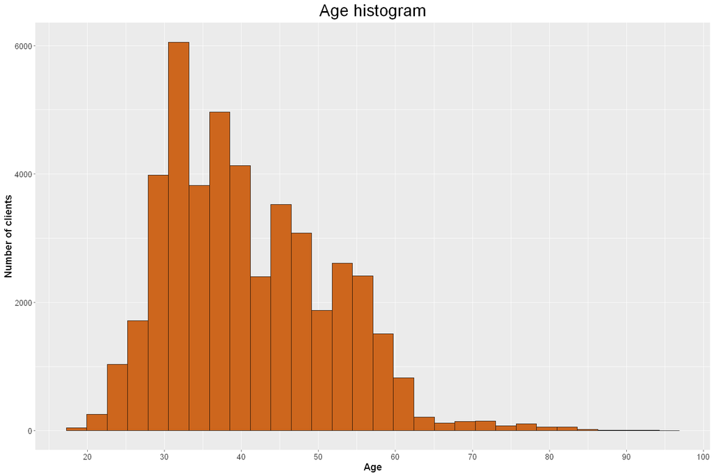

```r
# Age histogram

ggplot(df, aes(x = age)) + geom_histogram(color = "black", fill = "chocolate3") +
  scale_x_continuous(breaks = seq(10, 100, by = 10)) +
  theme(axis.text.x = element_text(size = 12),
        axis.title.x = element_text(size = 15, face = "bold"),
        axis.text.y = element_text(size = 12),
        axis.title.y = element_text(size = 15, face = "bold"),
        plot.title = element_text(size = 25, hjust = 0.5)) +
  labs(title = "Age histogram", x = "Age", y = "Number of clients")
```

By looking at the graph, we can see that the biggest part of the clients are raging from ~30 to 40 years old. After that, the number of clients tends to decrease as age increases. The biggest decrease in clients can be seen from ~58 years until the end of X-axis. The distribution appears to be right-skewed, meaning there are fewer older clients.

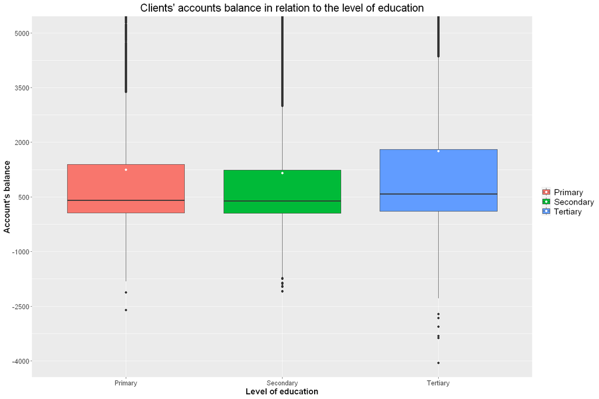

```r
# Balance-education box plot

df %>% subset(education != "unknown") %>%
  ggplot(aes(x = education, y = balance, fill =  education)) + geom_boxplot() + coord_cartesian(ylim = c(-4000, 5000)) +
  scale_y_continuous(breaks = seq(-4000, 5000, by = 1500)) + stat_summary(fun = mean, geom = "point", col = "white") +
  theme(axis.text.x = element_text(size = 12),
        axis.title.x = element_text(size = 15, face = "bold"),
        axis.text.y = element_text(size = 12),
        axis.title.y = element_text(size = 15, face = "bold"),
        plot.title = element_text(size = 20, hjust = 0.5),
        legend.text = element_text(size = 15)) +
  labs(
    title = "Clients' accounts balance in relation to the level of education",
    x = "Level of education",
    y = "Account's balance",
    fill = "") +
  scale_x_discrete(labels = c("Primary", "Secondary", "Tertiary")) +
  scale_fill_discrete(labels = c("Primary", "Secondary", "Tertiary"))
```

As discussed previosly, *balance* variable has major outliers both in positive and negative values. To have a better understanding of the data, it was chosen to apply restrictions to the Y-axis.

It appears that clients with tertiary education tend to have higher median balances in their accounts, as indicated by the higher median line in the blue box. An interesting observation is that the median balance for Primary education is higher than of Secondary. This implies that clients with Primary education have higher median balances than those with Secondary education.

The distribution of balances for clients with secondary education is more compact than for the other categories, as indicated by the shorter IQR (the box's height). Clients with primary and tertiary education have a wider range of balances (larger IQR).

There are outliers in all categories, with tertiary education showing outliers on both the high and low ends, indicating that clients with tertiary education have a more varied range of account balances.The box for tertiary education also extends higher than the other categories, suggesting that individuals in this group have higher upper quartiles, and the distribution is skewed towards higher values. This might be logical as people with higher education, on average, tend to earn more than those with lower level of education.

There are some extreme outliers for all levels of education which go up to 75 000+. It can also be seen that clients with Tertiary education tend to have the most outliers at the lower end. All in all this suggests that the dataset contains data from random clients which can be from lower, middle and upper classes.

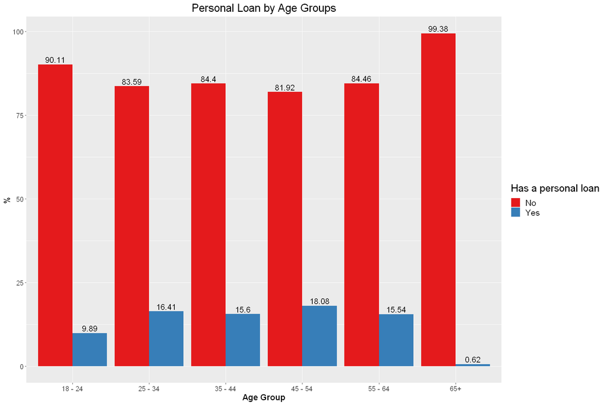

```r
# Grouped bar plot

loan_by_age <- as.data.frame(round(prop.table(table(df6$age_category, df$loan), 1) * 100, 2))

ggplot(loan_by_age, aes(x = Var1, y = Freq, fill = Var2)) +
geom_bar(stat = "identity", position = "dodge") +
geom_text(aes(label = Freq), position = position_dodge(width = 0.9), color = "black", vjust = -0.3, size = 5) +
theme(axis.text.x = element_text(size = 12),
      axis.title.x = element_text(size = 15, face = "bold"),
      axis.text.y = element_text(size = 12),
      axis.title.y = element_text(size = 15, face = "bold"),
      plot.title = element_text(size = 20, hjust = 0.5),
      legend.title = element_text(size = 18),
      legend.text = element_text(size = 15)) +
labs(
  title = "Personal Loan by Age Groups",
  x = "Age Group",
  y = "%",
  fill = "Has a personal loan") +
scale_fill_manual(values = brewer.pal(n = 3, name = "Set1"), labels = c("No", "Yes"))
```

We can also look at the percetange of clients in each age group in terms of having a personal loan. As can be seen from the graph, a very small percentage of clients in each age group has a personal loan. None of the age groups breach a 20% line with most of them staying in range from ~10 to 16%. As expected, the lowest percentage is for the age group 65+ which is to be expected.

Generally speaking, personal loans are not that popular as people tend to take loans mostly for housing. However, marketing strategy could still be improved.

```r
# Bar plot: 'job', 'marital', 'education', 'housing', 'loan'

job_df <- as.data.frame(job) %>% subset(Var1 != "unknown")
marital_df <- as.data.frame(marital)
edu_df <- as.data.frame(edu) %>% subset(Var1 != "unknown")

plot1 <- ggplot(job_df, aes(x = Var1, y = Freq, fill = Var1)) +
         geom_bar(stat = "identity") +
         labs(title = "Occupation", x = "Job Category", y = "%") +
         theme(axis.text.x = element_text(size = 12),
               axis.title.x = element_text(face = "bold"),
               axis.text.y = element_text(angle = 45, hjust = 1, size = 12),
               axis.title.y = element_text(face = "bold")) +
         scale_x_discrete(
          labels = c("Admin.", "Blue-collar", "Entrepreneur", "Housemaid", "Management", "Retired", "Self-employed",
                     "Services", "Student", "Technician", "Unemployed"))  +
         scale_fill_brewer(palette = "Paired") +
         theme(legend.position = "None") +
         coord_flip()

plot2 <- ggplot(marital_df, aes(x = Var1, y = Freq, fill = Var1)) +
         geom_bar(stat = "identity") +
         labs(title = "Marital Status", x = "Status", y = "%") +
         theme(axis.text.x = element_text(size = 12),
               axis.title.x = element_text(face = "bold"),
               axis.text.y = element_text(angle = 45, hjust = 1, size = 12),
               axis.title.y = element_text(face = "bold")) +
         scale_x_discrete(labels = c("Divorced", "Married", "Single")) +
         scale_fill_brewer(palette = "Paired") +
         theme(legend.position = "None") +
         coord_flip()

plot3 <- ggplot(edu_df, aes(x = Var1, y = Freq, fill = Var1)) +
         geom_bar(stat = "identity") +
         labs(title = "Level of education", x = "Education", y = "%") +
         theme(axis.text.x = element_text(size = 12),
               axis.title.x = element_text(face = "bold"),
               axis.text.y = element_text(angle = 45, hjust = 1, size = 12),
               axis.title.y = element_text(face = "bold")) +
         scale_x_discrete(labels = c("Primary", "Secondary", "Tertiary")) +
         scale_fill_brewer(palette = "Set2") +
         theme(legend.position = "None") +
         coord_flip()
```

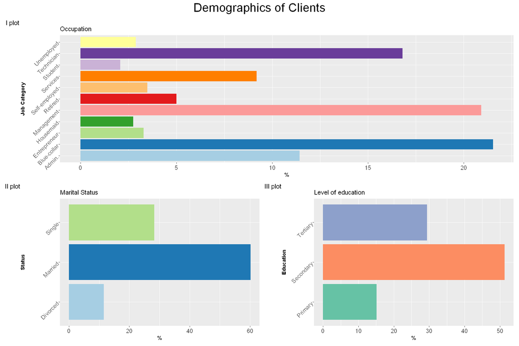

```r
plot1 / (plot2 | plot3) +
  plot_annotation(title = "Demographics of Clients", theme = theme(plot.title = element_text(hjust = 0.5, size = 25)),
                  tag_levels = "I", tag_suffix = " plot")
```

In the plots panel we have three graphs which represent the demographics of clients: occupation, marital status and level of education. This is the same information that was looked at before with proprotion tables. However, it is always more pleasing to see a graph instead of a table. By looking at the 1st plot we see that the two most popular occupations are *Management* and *Blue-collar* which both have over 20%. The third most popular occupation is *Technician* with a bit over 15%.

Next up, we have marital status and level of education. From the plots we see that majority of the clients are married and have a secondary level of education.

# 3) MODELLING TASK

Perform a logistic regression to obtain the predicted probability that a customer has subscribed for a term deposit. Use continuous variables and dummy variables created for categorical columns. Not necessarily all variables provided in data sample should be used. Evaluate model goodness of fit and predictive ability. If needed, data set could be split into training and test sets.

Response variable y.

```r
set.seed(123)

# Splitting dataset into train and test datasets

indexes <- sample(1:nrow(df), size = 0.7 * nrow(df))
train_set <- df[indexes, ]
test_set <- df[-indexes, ]


# Fitting the model

fit.null <- glm(y ~ 1, data = train_set, family = binomial)

fit.1 <- glm(y ~ ., data = train_set, family = binomial)
summary(fit.1)

# Since not all variables should be used, we begin excluding them by looking at the associated 'p-value'. If the value is
# less than 0.05, the variable is considered to be statistically significant and should not be excluded.
```

```
Call:
glm(formula = y ~ ., family = binomial, data = train_set)

Coefficients:
                     Estimate Std. Error z value Pr(>|z|)
(Intercept)        -2.500e+00  2.185e-01 -11.442  < 2e-16 ***
age                -2.367e-03  2.641e-03  -0.896 0.370229
jobblue-collar     -2.774e-01  8.657e-02  -3.205 0.001352 **
jobentrepreneur    -2.178e-01  1.465e-01  -1.486 0.137157
jobhousemaid       -5.092e-01  1.631e-01  -3.122 0.001795 **
jobmanagement      -1.421e-01  8.770e-02  -1.621 0.105108
jobretired          3.098e-01  1.176e-01   2.633 0.008452 **
jobself-employed   -2.709e-01  1.324e-01  -2.046 0.040765 *
jobservices        -2.439e-01  1.007e-01  -2.422 0.015442 *
jobstudent          3.345e-01  1.318e-01   2.538 0.011155 *
jobtechnician      -1.784e-01  8.210e-02  -2.173 0.029760 *
jobunemployed      -1.524e-01  1.311e-01  -1.162 0.245269
jobunknown         -4.290e-01  3.020e-01  -1.421 0.155401
maritalmarried     -1.975e-01  7.014e-02  -2.816 0.004860 **
maritalsingle       5.441e-02  8.021e-02   0.678 0.497520
educationsecondary  2.078e-01  7.753e-02   2.680 0.007352 **
educationtertiary   3.653e-01  9.009e-02   4.055 5.02e-05 ***
educationunknown    2.238e-01  1.253e-01   1.787 0.073973 .
defaultyes         -8.356e-02  1.938e-01  -0.431 0.666366
balance             2.132e-05  6.119e-06   3.485 0.000493 ***
housingyes         -6.749e-01  5.224e-02 -12.919  < 2e-16 ***
loanyes            -4.302e-01  7.140e-02  -6.024 1.70e-09 ***
contacttelephone   -1.811e-01  9.152e-02  -1.978 0.047893 *
contactunknown     -1.727e+00  8.822e-02 -19.574  < 2e-16 ***
day                 8.659e-03  2.990e-03   2.896 0.003777 **
monthaug           -7.954e-01  9.357e-02  -8.500  < 2e-16 ***
monthdec            6.192e-01  2.123e-01   2.916 0.003543 **
monthfeb           -1.642e-01  1.061e-01  -1.548 0.121652
monthjan           -1.311e+00  1.458e-01  -8.995  < 2e-16 ***
monthjul           -8.382e-01  9.093e-02  -9.219  < 2e-16 ***
monthjun            4.737e-01  1.114e-01   4.253 2.11e-05 ***
monthmay           -4.001e-01  8.545e-02  -4.682 2.84e-06 ***
monthmar            1.481e+00  1.458e-01  10.157  < 2e-16 ***
monthnov           -9.456e-01  1.009e-01  -9.373  < 2e-16 ***
monthoct            7.932e-01  1.297e-01   6.118 9.50e-10 ***
monthsep            9.491e-01  1.416e-01   6.704 2.02e-11 ***
duration            4.234e-03  7.785e-05  54.385  < 2e-16 ***
campaign           -7.514e-02  1.167e-02  -6.440 1.19e-10 ***
pdays              -6.218e-05  3.602e-04  -0.173 0.862952
previous            8.336e-03  6.526e-03   1.277 0.201510
poutcomeother       2.406e-01  1.074e-01   2.240 0.025099 *
poutcomesuccess     2.361e+00  9.866e-02  23.931  < 2e-16 ***
poutcomeunknown    -1.548e-04  1.107e-01  -0.001 0.998885
---
Signif. codes:  0 '***' 0.001 '**' 0.01 '*' 0.05 '.' 0.1 ' ' 1

(Dispersion parameter for binomial family taken to be 1)

    Null deviance: 22925  on 31646  degrees of freedom
Residual deviance: 15090  on 31604  degrees of freedom
AIC: 15176

Number of Fisher Scoring iterations: 6
```

```r
fit.2 <- update(fit.1, . ~ . - age)
summary(fit.2)
```

```
Call:
glm(formula = y ~ job + marital + education + default + balance +
    housing + loan + contact + day + month + duration + campaign +
    pdays + previous + poutcome, family = binomial, data = train_set)

Coefficients:
                     Estimate Std. Error z value Pr(>|z|)
(Intercept)        -2.613e+00  1.783e-01 -14.659  < 2e-16 ***
jobblue-collar     -2.748e-01  8.651e-02  -3.177 0.001489 **
jobentrepreneur    -2.221e-01  1.465e-01  -1.517 0.129380
jobhousemaid       -5.207e-01  1.627e-01  -3.200 0.001373 **
jobmanagement      -1.453e-01  8.763e-02  -1.658 0.097289 .
jobretired          2.635e-01  1.057e-01   2.492 0.012700 *
jobself-employed   -2.735e-01  1.324e-01  -2.065 0.038898 *
jobservices        -2.418e-01  1.007e-01  -2.402 0.016292 *
jobstudent          3.566e-01  1.294e-01   2.756 0.005855 **
jobtechnician      -1.783e-01  8.210e-02  -2.172 0.029840 *
jobunemployed      -1.539e-01  1.311e-01  -1.173 0.240668
jobunknown         -4.382e-01  3.017e-01  -1.452 0.146421
maritalmarried     -1.917e-01  6.986e-02  -2.745 0.006053 **
maritalsingle       7.928e-02  7.526e-02   1.053 0.292181
educationsecondary  2.152e-01  7.710e-02   2.791 0.005259 **
educationtertiary   3.759e-01  8.930e-02   4.210 2.56e-05 ***
educationunknown    2.224e-01  1.253e-01   1.775 0.075835 .
defaultyes         -8.141e-02  1.938e-01  -0.420 0.674378
balance             2.089e-05  6.099e-06   3.426 0.000613 ***
housingyes         -6.701e-01  5.197e-02 -12.894  < 2e-16 ***
loanyes            -4.291e-01  7.139e-02  -6.010 1.85e-09 ***
contacttelephone   -1.928e-01  9.063e-02  -2.128 0.033362 *
contactunknown     -1.729e+00  8.819e-02 -19.606  < 2e-16 ***
day                 8.657e-03  2.990e-03   2.896 0.003781 **
monthaug           -7.981e-01  9.351e-02  -8.535  < 2e-16 ***
monthdec            6.178e-01  2.123e-01   2.910 0.003612 **
monthfeb           -1.649e-01  1.061e-01  -1.554 0.120080
monthjan           -1.311e+00  1.458e-01  -8.991  < 2e-16 ***
monthjul           -8.374e-01  9.092e-02  -9.210  < 2e-16 ***
monthjun            4.742e-01  1.114e-01   4.257 2.07e-05 ***
monthmay           -3.984e-01  8.543e-02  -4.664 3.11e-06 ***
monthmar            1.478e+00  1.458e-01  10.141  < 2e-16 ***
monthnov           -9.472e-01  1.009e-01  -9.391  < 2e-16 ***
monthoct            7.885e-01  1.295e-01   6.087 1.15e-09 ***
monthsep            9.469e-01  1.415e-01   6.690 2.23e-11 ***
duration            4.234e-03  7.785e-05  54.383  < 2e-16 ***
campaign           -7.519e-02  1.167e-02  -6.443 1.17e-10 ***
pdays              -6.298e-05  3.602e-04  -0.175 0.861205
previous            8.312e-03  6.523e-03   1.274 0.202584
poutcomeother       2.419e-01  1.074e-01   2.252 0.024317 *
poutcomesuccess     2.359e+00  9.862e-02  23.921  < 2e-16 ***
poutcomeunknown     1.513e-03  1.107e-01   0.014 0.989100
---
Signif. codes:  0 '***' 0.001 '**' 0.01 '*' 0.05 '.' 0.1 ' ' 1

(Dispersion parameter for binomial family taken to be 1)

    Null deviance: 22925  on 31646  degrees of freedom
Residual deviance: 15090  on 31605  degrees of freedom
AIC: 15174

Number of Fisher Scoring iterations: 6
```

```r
fit.3 <- update(fit.2, . ~ . - pdays)
summary(fit.3)
```

```
Call:
glm(formula = y ~ job + marital + education + default + balance +
    housing + loan + contact + day + month + duration + campaign +
    previous + poutcome, family = binomial, data = train_set)

Coefficients:
                     Estimate Std. Error z value Pr(>|z|)
(Intercept)        -2.628e+00  1.560e-01 -16.847  < 2e-16 ***
jobblue-collar     -2.749e-01  8.651e-02  -3.178 0.001482 **
jobentrepreneur    -2.220e-01  1.465e-01  -1.516 0.129522
jobhousemaid       -5.204e-01  1.627e-01  -3.199 0.001381 **
jobmanagement      -1.454e-01  8.763e-02  -1.659 0.097091 .
jobretired          2.637e-01  1.057e-01   2.494 0.012625 *
jobself-employed   -2.732e-01  1.324e-01  -2.063 0.039097 *
jobservices        -2.420e-01  1.007e-01  -2.404 0.016234 *
jobstudent          3.572e-01  1.294e-01   2.761 0.005771 **
jobtechnician      -1.782e-01  8.209e-02  -2.170 0.029986 *
jobunemployed      -1.541e-01  1.311e-01  -1.175 0.239963
jobunknown         -4.380e-01  3.017e-01  -1.452 0.146537
maritalmarried     -1.916e-01  6.985e-02  -2.743 0.006086 **
maritalsingle       7.929e-02  7.526e-02   1.053 0.292129
educationsecondary  2.151e-01  7.710e-02   2.790 0.005267 **
educationtertiary   3.762e-01  8.928e-02   4.214 2.51e-05 ***
educationunknown    2.226e-01  1.253e-01   1.777 0.075571 .
defaultyes         -8.177e-02  1.938e-01  -0.422 0.673002
balance             2.089e-05  6.099e-06   3.426 0.000612 ***
housingyes         -6.709e-01  5.179e-02 -12.954  < 2e-16 ***
loanyes            -4.292e-01  7.139e-02  -6.011 1.84e-09 ***
contacttelephone   -1.928e-01  9.063e-02  -2.128 0.033352 *
contactunknown     -1.729e+00  8.816e-02 -19.609  < 2e-16 ***
day                 8.663e-03  2.990e-03   2.898 0.003758 **
monthaug           -7.977e-01  9.348e-02  -8.534  < 2e-16 ***
monthdec            6.179e-01  2.123e-01   2.910 0.003611 **
monthfeb           -1.639e-01  1.059e-01  -1.547 0.121772
monthjan           -1.310e+00  1.457e-01  -8.990  < 2e-16 ***
monthjul           -8.371e-01  9.090e-02  -9.208  < 2e-16 ***
monthjun            4.747e-01  1.114e-01   4.263 2.02e-05 ***
monthmay           -3.989e-01  8.538e-02  -4.672 2.98e-06 ***
monthmar            1.479e+00  1.457e-01  10.149  < 2e-16 ***
monthnov           -9.455e-01  1.004e-01  -9.418  < 2e-16 ***
monthoct            7.893e-01  1.295e-01   6.096 1.09e-09 ***
monthsep            9.467e-01  1.415e-01   6.690 2.24e-11 ***
duration            4.234e-03  7.785e-05  54.383  < 2e-16 ***
campaign           -7.522e-02  1.167e-02  -6.445 1.15e-10 ***
previous            8.339e-03  6.526e-03   1.278 0.201269
poutcomeother       2.432e-01  1.072e-01   2.269 0.023279 *
poutcomesuccess     2.363e+00  9.555e-02  24.735  < 2e-16 ***
poutcomeunknown     1.629e-02  7.162e-02   0.227 0.820062
---
Signif. codes:  0 '***' 0.001 '**' 0.01 '*' 0.05 '.' 0.1 ' ' 1

(Dispersion parameter for binomial family taken to be 1)

    Null deviance: 22925  on 31646  degrees of freedom
Residual deviance: 15090  on 31606  degrees of freedom
AIC: 15172

Number of Fisher Scoring iterations: 6
```

```r
fit.4 <- update(fit.3, . ~ . - previous)
summary(fit.4)
```

```
Call:
glm(formula = y ~ job + marital + education + default + balance +
    housing + loan + contact + day + month + duration + campaign +
    poutcome, family = binomial, data = train_set)

Coefficients:
                     Estimate Std. Error z value Pr(>|z|)
(Intercept)        -2.606e+00  1.550e-01 -16.811  < 2e-16 ***
jobblue-collar     -2.760e-01  8.650e-02  -3.191  0.00142 **
jobentrepreneur    -2.228e-01  1.464e-01  -1.521  0.12821
jobhousemaid       -5.212e-01  1.627e-01  -3.204  0.00136 **
jobmanagement      -1.444e-01  8.762e-02  -1.648  0.09927 .
jobretired          2.628e-01  1.057e-01   2.486  0.01293 *
jobself-employed   -2.739e-01  1.324e-01  -2.068  0.03861 *
jobservices        -2.431e-01  1.007e-01  -2.415  0.01573 *
jobstudent          3.570e-01  1.294e-01   2.760  0.00578 **
jobtechnician      -1.781e-01  8.209e-02  -2.170  0.03001 *
jobunemployed      -1.548e-01  1.311e-01  -1.180  0.23788
jobunknown         -4.378e-01  3.017e-01  -1.451  0.14673
maritalmarried     -1.907e-01  6.985e-02  -2.729  0.00635 **
maritalsingle       7.972e-02  7.527e-02   1.059  0.28953
educationsecondary  2.144e-01  7.710e-02   2.781  0.00542 **
educationtertiary   3.755e-01  8.928e-02   4.206 2.60e-05 ***
educationunknown    2.217e-01  1.253e-01   1.770  0.07674 .
defaultyes         -8.239e-02  1.938e-01  -0.425  0.67078
balance             2.090e-05  6.099e-06   3.427  0.00061 ***
housingyes         -6.694e-01  5.177e-02 -12.930  < 2e-16 ***
loanyes            -4.288e-01  7.139e-02  -6.006 1.90e-09 ***
contacttelephone   -1.914e-01  9.061e-02  -2.112  0.03469 *
contactunknown     -1.728e+00  8.816e-02 -19.605  < 2e-16 ***
day                 8.610e-03  2.989e-03   2.880  0.00398 **
monthaug           -7.962e-01  9.348e-02  -8.518  < 2e-16 ***
monthdec            6.201e-01  2.122e-01   2.922  0.00348 **
monthfeb           -1.605e-01  1.059e-01  -1.516  0.12943
monthjan           -1.308e+00  1.457e-01  -8.972  < 2e-16 ***
monthjul           -8.353e-01  9.090e-02  -9.190  < 2e-16 ***
monthjun            4.763e-01  1.113e-01   4.278 1.88e-05 ***
monthmay           -3.980e-01  8.538e-02  -4.662 3.13e-06 ***
monthmar            1.481e+00  1.457e-01  10.164  < 2e-16 ***
monthnov           -9.442e-01  1.004e-01  -9.406  < 2e-16 ***
monthoct            7.919e-01  1.295e-01   6.116 9.57e-10 ***
monthsep            9.495e-01  1.415e-01   6.710 1.95e-11 ***
duration            4.234e-03  7.785e-05  54.381  < 2e-16 ***
campaign           -7.486e-02  1.166e-02  -6.421 1.35e-10 ***
poutcomeother       2.527e-01  1.069e-01   2.365  0.01805 *
poutcomesuccess     2.365e+00  9.555e-02  24.755  < 2e-16 ***
poutcomeunknown    -7.785e-03  6.905e-02  -0.113  0.91024
---
Signif. codes:  0 '***' 0.001 '**' 0.01 '*' 0.05 '.' 0.1 ' ' 1

(Dispersion parameter for binomial family taken to be 1)

    Null deviance: 22925  on 31646  degrees of freedom
Residual deviance: 15092  on 31607  degrees of freedom
AIC: 15172

Number of Fisher Scoring iterations: 6
```

```r
fit.5 <- update(fit.4, . ~ . - default)
summary(fit.5)
```

```
Call:
glm(formula = y ~ job + marital + education + balance + housing +
    loan + contact + day + month + duration + campaign + poutcome,
    family = binomial, data = train_set)

Coefficients:
                     Estimate Std. Error z value Pr(>|z|)
(Intercept)        -2.606e+00  1.550e-01 -16.811  < 2e-16 ***
jobblue-collar     -2.764e-01  8.649e-02  -3.196 0.001394 **
jobentrepreneur    -2.252e-01  1.464e-01  -1.539 0.123911
jobhousemaid       -5.216e-01  1.627e-01  -3.206 0.001347 **
jobmanagement      -1.453e-01  8.760e-02  -1.659 0.097183 .
jobretired          2.625e-01  1.057e-01   2.483 0.013029 *
jobself-employed   -2.751e-01  1.324e-01  -2.078 0.037710 *
jobservices        -2.432e-01  1.007e-01  -2.416 0.015680 *
jobstudent          3.576e-01  1.294e-01   2.764 0.005710 **
jobtechnician      -1.785e-01  8.209e-02  -2.174 0.029708 *
jobunemployed      -1.550e-01  1.311e-01  -1.182 0.237136
jobunknown         -4.377e-01  3.017e-01  -1.451 0.146824
maritalmarried     -1.904e-01  6.985e-02  -2.725 0.006421 **
maritalsingle       7.955e-02  7.526e-02   1.057 0.290534
educationsecondary  2.142e-01  7.709e-02   2.778 0.005468 **
educationtertiary   3.760e-01  8.927e-02   4.212 2.53e-05 ***
educationunknown    2.216e-01  1.253e-01   1.769 0.076864 .
balance             2.103e-05  6.092e-06   3.451 0.000558 ***
housingyes         -6.692e-01  5.176e-02 -12.928  < 2e-16 ***
loanyes            -4.309e-01  7.124e-02  -6.048 1.46e-09 ***
contacttelephone   -1.909e-01  9.061e-02  -2.106 0.035178 *
contactunknown     -1.729e+00  8.815e-02 -19.615  < 2e-16 ***
day                 8.613e-03  2.989e-03   2.881 0.003961 **
monthaug           -7.970e-01  9.346e-02  -8.527  < 2e-16 ***
monthdec            6.202e-01  2.123e-01   2.922 0.003479 **
monthfeb           -1.608e-01  1.059e-01  -1.519 0.128737
monthjan           -1.308e+00  1.458e-01  -8.975  < 2e-16 ***
monthjul           -8.369e-01  9.084e-02  -9.213  < 2e-16 ***
monthjun            4.761e-01  1.113e-01   4.275 1.91e-05 ***
monthmay           -3.983e-01  8.538e-02  -4.665 3.09e-06 ***
monthmar            1.481e+00  1.457e-01  10.165  < 2e-16 ***
monthnov           -9.452e-01  1.004e-01  -9.418  < 2e-16 ***
monthoct            7.920e-01  1.295e-01   6.117 9.55e-10 ***
monthsep            9.497e-01  1.415e-01   6.711 1.94e-11 ***
duration            4.234e-03  7.785e-05  54.385  < 2e-16 ***
campaign           -7.487e-02  1.166e-02  -6.422 1.35e-10 ***
poutcomeother       2.522e-01  1.069e-01   2.360 0.018274 *
poutcomesuccess     2.366e+00  9.555e-02  24.758  < 2e-16 ***
poutcomeunknown    -8.220e-03  6.905e-02  -0.119 0.905237
---
Signif. codes:  0 '***' 0.001 '**' 0.01 '*' 0.05 '.' 0.1 ' ' 1

(Dispersion parameter for binomial family taken to be 1)

    Null deviance: 22925  on 31646  degrees of freedom
Residual deviance: 15092  on 31608  degrees of freedom
AIC: 15170

Number of Fisher Scoring iterations: 6
```

Having excluded the variables which were statistically insignificant, we are left with the 5th model (*fit.5*).

One of the requirements for logistic regression is that the independent variables must be unrelated to one another. Thus, it is essential to test for multicolinearity.

```r
vif <- vif(fit.5)
vif
```

A matrix: 12 × 3 of type dbl

|  | GVIF | Df | GVIF^(1/(2*Df)) |
| --- | --- | --- | --- |
| job | 2.938300 | 11 | 1.050212 |
| marital | 1.179311 | 2 | 1.042094 |
| education | 2.214575 | 3 | 1.141691 |
| balance | 1.034371 | 1 | 1.017040 |
| housing | 1.393949 | 1 | 1.180656 |
| loan | 1.060595 | 1 | 1.029852 |
| contact | 1.844638 | 2 | 1.165407 |
| day | 1.353702 | 1 | 1.163487 |
| month | 3.621055 | 11 | 1.060234 |
| duration | 1.121506 | 1 | 1.059012 |
| campaign | 1.101204 | 1 | 1.049383 |
| poutcome | 1.225479 | 3 | 1.034469 |

Providing that *VIF* values for all the variables are approximately equal to 1 suggests that there is no correlation between independent variables.

**Goodness of fit**

```r
AIC_null <- AIC(fit.null)
AIC_fit.5 <- AIC(fit.5)

AIC_null - AIC_fit.5
```

7756.81313582015

```r
fit.5_deviance <- deviance(fit.5)
fit.5_null_deviance <- fit.5$null.deviance

fit.5_deviance
fit.5_null_deviance
fit.5_null_deviance - fit.5_deviance
```

15092.2307157887

22925.0438516089

7832.81313582014

This indicates that the model successfully captures significant patterns in the data that the null model does not. It is safe to say that that the reduction in deviance contributes to the statistical significance of a model. The included variables contribute important information for predicting the dependent variable.

**Predictive ability**

```r
predictions <- predict(fit.5, test_set, type = "response")

roc_curve <- roc(test_set$y, predictions)
auc(roc_curve)
```

0.902716597934479

```r
predicted_classes <- ifelse(predictions > 0.5, "yes", "no")
confusion_matrix <- table(Predicted = predicted_classes, Actual = test_set$y)
confusion_matrix
round(prop.table(confusion_matrix) * 100, 2)
```

```
         Actual
Predicted    no   yes
      yes   308   544
      no  11690  1022
```

```
         Actual
Predicted    no   yes
      yes  2.27  4.01
      no  86.18  7.53
```

It is very important to note that there is strong imbalance in the values of dependent variable ('y'). Approximately only 12% of 'yes' values and about 88% of 'no' values, is a significant factor contributing to the model's performance, particularly its poorer performance on predicting 'yes' values accurately.

```r
y <- prop.tables[[10]]
y
```

```
      no      yes
88.30152 11.69848
```